# Chapter 10

Julin N Maloof

5/16/2018

## Q6

### a. *explain what is meant by explains 10% of the variation*

The total variance is the sum of the variance present in each tissue sample. Variance along the first principal component is 1/10 of this sum.

### b.

The first PC may not perfectly map to the machine type. For example, if by random chance more T (or C) were run on machine A or B that could be a problem.

Better to me seems to do do a regression that include T vs C and A vs B

### c *simulation*

```r
library(tidyverse)
genes <- 1000
samples <- 100
data <- rnorm(genes*samples) %>% matrix(nrow=genes)
```

```r
machine <- c(sample(c("A","B"),50,replace = TRUE, prob = c(.8,.2)),
             sample(c("A","B"),50,replace = TRUE, prob = c(.2,.8)))
```

Q8

## Q9

*Consider the USArrests data. We will now perform hierarchical clustering on the states.*

*(a) Using hierarchical clustering with complete linkage and Euclidean distance, cluster the states.*

```r
library(tidyverse)
library(ISLR)
library(ggdendro)
data("USArrests")

head(USArrests)
```

```
##            Murder Assault UrbanPop Rape
## Alabama      13.2     236       58 21.2
## Alaska       10.0     263       48 44.5
## Arizona       8.1     294       80 31.0
## Arkansas      8.8     190       50 19.5
## California    9.0     276       91 40.6
## Colorado      7.9     204       78 38.7
```

```r
summary(USArrests)
```

```
##      Murder          Assault         UrbanPop          Rape
##  Min.   : 0.800   Min.   : 45.0   Min.   :32.00   Min.   : 7.30
##  1st Qu.: 4.075   1st Qu.:109.0   1st Qu.:54.50   1st Qu.:15.07
##  Median : 7.250   Median :159.0   Median :66.00   Median :20.10
##  Mean   : 7.788   Mean   :170.8   Mean   :65.54   Mean   :21.23
##  3rd Qu.:11.250   3rd Qu.:249.0   3rd Qu.:77.75   3rd Qu.:26.18
##  Max.   :17.400   Max.   :337.0   Max.   :91.00   Max.   :46.00
```

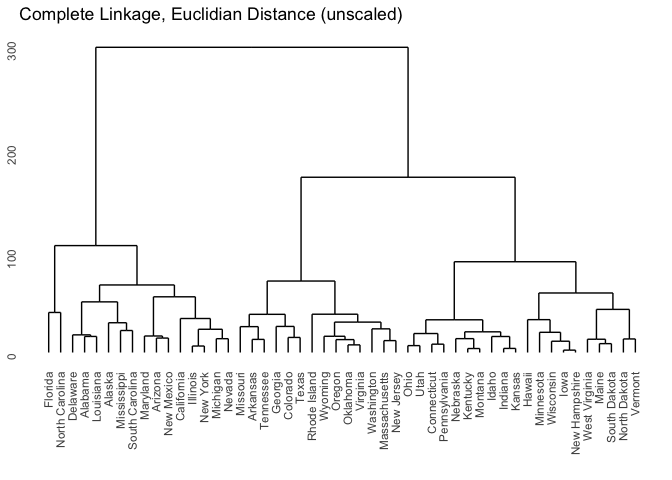

```r
hcl.complete.euc <- hclust(dist(USArrests))

ggdendrogram(hcl.complete.euc) + ggtitle("Complete Linkage, Euclidian Distance (unscaled)")
```

*(b) Cut the dendrogram at a height that results in three distinct clusters. Which states belong to which clusters?*

```r
clusters.complete.euc <- tibble(
  label=names(cutree(hcl.complete.euc,3)),
  cluster=as.character(cutree(hcl.complete.euc,3)))
clusters.complete.euc
```

```
## # A tibble: 50 x 2
##          label cluster
##          <chr>   <chr>
##  1     Alabama       1
##  2      Alaska       1
##  3     Arizona       1
##  4    Arkansas       2
##  5  California       1
##  6    Colorado       2
##  7 Connecticut       3
##  8    Delaware       1
##  9     Florida       1
## 10     Georgia       2
## # ... with 40 more rows
```

```r
hclust.data <- dendro_data(hcl.complete.euc)
lab <- left_join(label(hclust.data),clusters.complete.euc)
lab
```

```
##     x y          label cluster
## 1   1 0        Florida       1
## 2   2 0 North Carolina       1
## 3   3 0       Delaware       1
## 4   4 0        Alabama       1
## 5   5 0      Louisiana       1
## 6   6 0         Alaska       1
## 7   7 0    Mississippi       1
## 8   8 0 South Carolina       1
## 9   9 0       Maryland       1
## 10 10 0        Arizona       1
## 11 11 0     New Mexico       1
## 12 12 0     California       1
## 13 13 0       Illinois       1
## 14 14 0       New York       1
```

[output cut: 36 more lines]

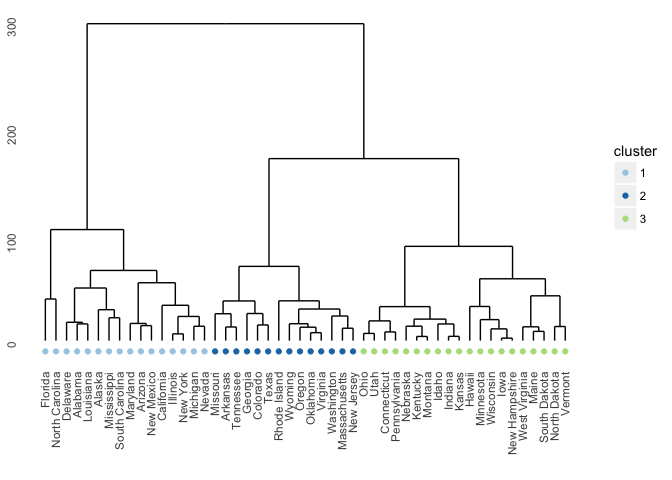

```r
hclust.data <- dendro_data(hcl.complete.euc)
pl <- ggdendrogram(hcl.complete.euc)
pl + geom_point(aes(x=x,y=y-10,color=cluster),data=lab) +
  scale_color_brewer(type="qual",palette = 3)
```

*(c) Hierarchically cluster the states using complete linkage and Euclidean distance, after scaling the variables to have standard deviation one.*

```r
hcl.complete.euc.scale <- USArrests %>% scale() %>% dist() %>% hclust()

hclust.data.scale <- dendro_data(hcl.complete.euc.scale)

clusters.complete.euc.scale <- tibble(
  label=names(cutree(hcl.complete.euc.scale,3)),
  cluster=as.character(cutree(hcl.complete.euc.scale,3)))
clusters.complete.euc.scale
```

```
## # A tibble: 50 x 2
##          label cluster
##          <chr>   <chr>
##  1     Alabama       1
##  2      Alaska       1
##  3     Arizona       2
##  4    Arkansas       3
##  5  California       2
##  6    Colorado       2
##  7 Connecticut       3
##  8    Delaware       3
##  9     Florida       2
## 10     Georgia       1
## # ... with 40 more rows
```

```r
lab <- left_join(label(hclust.data.scale),clusters.complete.euc.scale)
lab
```

```
##     x y          label cluster
## 1   1 0   South Dakota       3
## 2   2 0  West Virginia       3
## 3   3 0   North Dakota       3
## 4   4 0        Vermont       3
## 5   5 0          Maine       3
## 6   6 0           Iowa       3
## 7   7 0  New Hampshire       3
## 8   8 0          Idaho       3
## 9   9 0        Montana       3
## 10 10 0       Nebraska       3
## 11 11 0       Kentucky       3
## 12 12 0       Arkansas       3
## 13 13 0       Virginia       3
## 14 14 0        Wyoming       3
```

[output cut: 36 more lines]

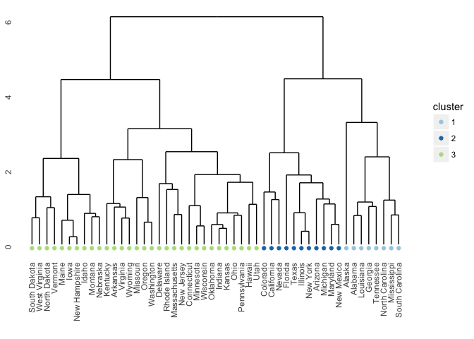

```r
hclust.data <- dendro_data(hcl.complete.euc.scale)
pl <- ggdendrogram(hcl.complete.euc.scale)
pl + geom_point(aes(x=x,y=y-.1,color=cluster),data=lab) +
  scale_color_brewer(type="qual",palette = 3)
```

*(d) What effect does scaling the variables have on the hierarchical clustering obtained? In your opinion, should the variables be scaled before the inter-observation dissimilarities are computed? Provide a justification for your answer.*

Unscaled, the states are split into three pretty equal groups and these are clearly separated. Scaled one group dominates with two smaller groups, and the distinctions are less clear. A heat map may help…